# UNIT 10 HW

Mark Mastrangeli

11/12/2018

# A. Clean an prepare the data:

### 1. Create column for brewery ID that is common to both datasets similar to what you did in the project. So we can merge!

### 2. Merge the beer and brewery data into a single dataframe.

### 3. Clean the State Column … get rid of extraneous white space.

### 4. Create One Dataset that has only Colorado and Texas beers and no IBU NAs … name it “beerCOTX”

### 5. Order beerCOTX by IBU (ascending) … this will be important later in graphing

```r
# Create column for brewery ID that is common to both DFs so we can merge.
breweries = breweries %>% mutate(Brewery_id = Brew_ID)
# Merge beer and brewery data.
beerDF = merge(beer,breweries,"Brewery_id")
# Clean the State Column
beerDF = beerDF %>% mutate(State = as.factor(trimws(State)))
colnames(beerDF) <- c("Brewery_ID", "Beer_Name", "Beer_ID", "ABV", "IBU", "Style", "Ounces", "Brew_ID", "Brewery_Name", "City", "State")

#Create One Dataset that has both Colorado and Texas and no IBU NAs.
beerCOTX = beerDF %>% filter(!is.na(IBU)) %>% filter(State == "CO" | State == "TX")
#plot  ABV v. IBU for both Colorado and Texas
```

### 6. Plot ABV v. IBU for both Colorado and Texas (two separate plots) … use ggplot and facets.

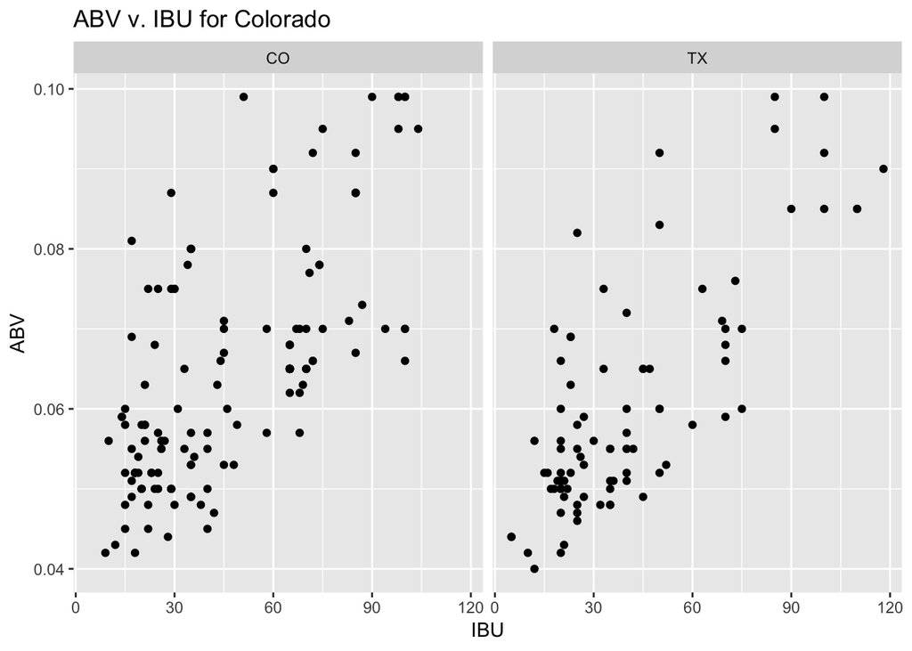

```r
beerCOTX %>% ggplot(aes(x = IBU, y = ABV)) + facet_wrap(~State) + geom_point() + labs(title = "ABV v. IBU for Colorado")
```

```r
#Order beerCOTX by IBU ... this will be important later in graphing
beerCOTX = beerCOTX[order(beerCOTX$IBU),]
beerCOTX$IBU2 = beerCOTX$IBU^2
head(beerCOTX)
```

```
##     Brewery_ID             Beer_Name Beer_ID   ABV IBU
## 31          67    Yo Soy Un Berliner    2520 0.044   5
## 92         129 18th Anniversary Gose    2370 0.044   5
## 184        392           Agave Wheat    1522 0.042   9
## 8           38          White Rascal     108 0.056  10
## 29          67               Rye Wit    2522 0.042  10
## 143        188             Lobo Lito    2238 0.040  12
##                       Style Ounces Brew_ID               Brewery_Name
## 31       Berliner Weissbier     12      67   Freetail Brewing Company
## 92                     Gose     12     129   Real Ale Brewing Company
## 184 American Pale Wheat Ale     12     392       Breckenridge Brewery
## 8                   Witbier     12      38      Avery Brewing Company
## 29                  Witbier     12      67   Freetail Brewing Company
## 143             Light Lager     12     188 Pedernales Brewing Company
##               City State IBU2
## 31     San Antonio    TX   25
## 92          Blanco    TX   25
## 184         Denver    CO   81
## 8          Boulder    CO  100
## 29     San Antonio    TX  100
## 143 Fredericksburg    TX  144
```

### 7. For each state, fit a simple linear regression model (Model 1: ABV= β_0+β_1 IBU) to assess the relationship between ABV and IBU. Use the regular plot function in base R (not ggplot) to create a scatter plot with the regression line superimposed on the plot. Again, this should be done for each state.

```r
# Fit a linear regression model to the data from each state
fitCO = lm(ABV~IBU,data = filter(beerCOTX,State == "CO"))
summary(fitCO)
```

```
##
## Call:
## lm(formula = ABV ~ IBU, data = filter(beerCOTX, State == "CO"))
##
## Residuals:
##       Min        1Q    Median        3Q       Max
## -0.018158 -0.007266 -0.003293  0.006453  0.032853
##
## Coefficients:
##              Estimate Std. Error t value Pr(>|t|)
## (Intercept) 4.740e-02  1.856e-03   25.54   <2e-16 ***
## IBU         3.676e-04  3.432e-05   10.71   <2e-16 ***
## ---
## Signif. codes:  0 '***' 0.001 '**' 0.01 '*' 0.05 '.' 0.1 ' ' 1
##
## Residual standard error: 0.01077 on 144 degrees of freedom
## Multiple R-squared:  0.4433, Adjusted R-squared:  0.4395
## F-statistic: 114.7 on 1 and 144 DF,  p-value: < 2.2e-16
```

```r
fitTX = lm(ABV~IBU,data = filter(beerCOTX,State == "TX"))
summary(fitTX)
```

```
##
## Call:
## lm(formula = ABV ~ IBU, data = filter(beerCOTX, State == "TX"))
##
## Residuals:
##       Min        1Q    Median        3Q       Max
## -0.014764 -0.005738 -0.001560  0.003182  0.028096
##
## Coefficients:
##              Estimate Std. Error t value Pr(>|t|)
## (Intercept) 4.347e-02  1.772e-03   24.54   <2e-16 ***
## IBU         4.172e-04  3.683e-05   11.33   <2e-16 ***
## ---
## Signif. codes:  0 '***' 0.001 '**' 0.01 '*' 0.05 '.' 0.1 ' ' 1
##
## Residual standard error: 0.009078 on 87 degrees of freedom
## Multiple R-squared:  0.596,  Adjusted R-squared:  0.5914
## F-statistic: 128.3 on 1 and 87 DF,  p-value: < 2.2e-16
```

### 8. Address the assumptions of the regression model. You may assume the data are independent (even if this is a stretch.): 1. There is a normal distribution of the ABV for fixed values of IBU. 2. These normal distributions have equal standard deviations. 3. The means of these normal distributions have a linear relationship with IBU. 4. Independence ( you may assume this one to be true without defense.)

#### There is not significant evidence agianst the assumption ABV is norally disriuted for each subpopulation of IBU.

#### This not signficant evidence against the assumption that the means of the assumed normal distributions of AVB given the IBU are linearly related to the value of IBU.

#### There is not significant evidence against the assumption that the normal distributions of ABV given IBU have the same standard deviations.

#### We are assuming that the observations are independent.

### 9. Make sure and print the parameter estimate table. Interpret the slope of the regression model. You should have one sentence for each interpretation. In addition, answer the question: Is there evidence that he relationship between ABV and IBU is significantly different for Texas and Colorado beers? For now, this is a judgement call.

```r
# Fit a linear regression model to the data from each state
fitCO = lm(ABV~IBU,data = filter(beerCOTX,State == "CO"))
summary(fitCO)
```

```
##
## Call:
## lm(formula = ABV ~ IBU, data = filter(beerCOTX, State == "CO"))
##
## Residuals:
##       Min        1Q    Median        3Q       Max
## -0.018158 -0.007266 -0.003293  0.006453  0.032853
##
## Coefficients:
##              Estimate Std. Error t value Pr(>|t|)
## (Intercept) 4.740e-02  1.856e-03   25.54   <2e-16 ***
## IBU         3.676e-04  3.432e-05   10.71   <2e-16 ***
## ---
## Signif. codes:  0 '***' 0.001 '**' 0.01 '*' 0.05 '.' 0.1 ' ' 1
##
## Residual standard error: 0.01077 on 144 degrees of freedom
## Multiple R-squared:  0.4433, Adjusted R-squared:  0.4395
## F-statistic: 114.7 on 1 and 144 DF,  p-value: < 2.2e-16
```

```r
COcoefs <- coef(fitCO)
COsigma <- sigma(fitCO)
fitCO_r2 <- COcoefs[1]
fitTX = lm(ABV~IBU,data = filter(beerCOTX,State == "TX"))
summary(fitTX)
```

```
##
## Call:
## lm(formula = ABV ~ IBU, data = filter(beerCOTX, State == "TX"))
##
## Residuals:
##       Min        1Q    Median        3Q       Max
## -0.014764 -0.005738 -0.001560  0.003182  0.028096
##
## Coefficients:
##              Estimate Std. Error t value Pr(>|t|)
## (Intercept) 4.347e-02  1.772e-03   24.54   <2e-16 ***
## IBU         4.172e-04  3.683e-05   11.33   <2e-16 ***
## ---
## Signif. codes:  0 '***' 0.001 '**' 0.01 '*' 0.05 '.' 0.1 ' ' 1
##
## Residual standard error: 0.009078 on 87 degrees of freedom
## Multiple R-squared:  0.596,  Adjusted R-squared:  0.5914
## F-statistic: 128.3 on 1 and 87 DF,  p-value: < 2.2e-16
```

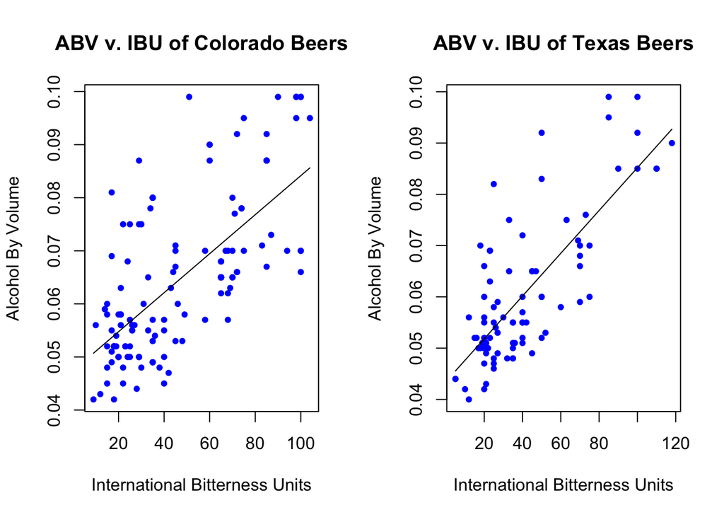

```r
TXcoefs <- coef(fitTX)
TXsigma <- sigma(fitTX)
fitTX_r2 <- TXcoefs[1]
#use each regression line to predict the ABV for the given IBUs.
predsCO = predict(fitCO)
predsTX = predict(fitTX)
#for each state / regression line provide a scatter plot with a regerssion line (do not use ggplot2 here)
par(mfrow = c(1,2))



plot(filter(beerCOTX,State == "CO")$IBU,filter(beerCOTX,State == "CO")$ABV, pch = 20, col = "blue", xlab = "International Bitterness Units", ylab = "Alcohol By Volume", main = "ABV v. IBU of Colorado Beers")
lines(filter(beerCOTX,State == "CO")$IBU,predsCO)



plot(filter(beerCOTX,State == "TX")$IBU,filter(beerCOTX,State == "TX")$ABV, pch = 20, col = "blue", xlab = "International Bitterness Units", ylab = "Alcohol By Volume", main = "ABV v. IBU of Texas Beers")
lines(filter(beerCOTX,State == "TX")$IBU,predsTX)
```

#### Colorado: For every additional unit of IBU the esitmated mean ABV increases .000367 units.

#### Texas: For every additional unit of IBU the esitmated mean ABV increases .000417 units.

#### While the sample slopes are different, I don’t believe they are far enough apart to suggest that this is not just because of smapleing error. (This is an opinion not backed by any objective test at this point. Any clear and thorough answer will do.)

### 10. Provide a confidence interval for each slope (from each state). Provide a sentence that interprets each slope (for each state) but this time include the confidence interval in your interpretation. See the Unit 9 6371 slides for an example of how to write the interpretation of the confidence interval. If you are not in 6371 and have not had it, ask a friend in the class to see the slides and discuss how to move forward. In short, the confidence interval contains the plausible values of the parameter (the slope in this case) given the data you observed. Given this new information, answer this question: Is there significant evidence that he relationship between ABV and IBU is significantly different for Texas and Colorado beers? This question is less subjective now and has a clear answer based on the plausible values for the parameters.

```r
confint(fitCO)
```

```
##                   2.5 %       97.5 %
## (Intercept) 0.043732505 0.0510700022
## IBU         0.000299726 0.0004354124
```

```r
confint(fitTX)
```

```
##                   2.5 %       97.5 %
## (Intercept) 0.039952379 0.0469949413
## IBU         0.000344007 0.0004903987
```

#### Remember that the confidence interval contains the plausible values for the slope given each state’s data. Since the confidence itnervals overlap, it is plausible that they may be the same. There is not enough evidence to suggest that the relationship (slope) between ABV and IBU is different for Colorado and Texas.

### 11. Using the beerCOTX dataframe, add a column to the data that is the square of the IBU column. Call it IBU2. Print the head of the dataframe with the new column.

```r
#fit the first model to the training set
beerCOTX$IBU2 = beerCOTX$IBU^2
head(beerCOTX)
```

```
##     Brewery_ID             Beer_Name Beer_ID   ABV IBU
## 31          67    Yo Soy Un Berliner    2520 0.044   5
## 92         129 18th Anniversary Gose    2370 0.044   5
## 184        392           Agave Wheat    1522 0.042   9
## 8           38          White Rascal     108 0.056  10
## 29          67               Rye Wit    2522 0.042  10
## 143        188             Lobo Lito    2238 0.040  12
##                       Style Ounces Brew_ID               Brewery_Name
## 31       Berliner Weissbier     12      67   Freetail Brewing Company
## 92                     Gose     12     129   Real Ale Brewing Company
## 184 American Pale Wheat Ale     12     392       Breckenridge Brewery
## 8                   Witbier     12      38      Avery Brewing Company
## 29                  Witbier     12      67   Freetail Brewing Company
## 143             Light Lager     12     188 Pedernales Brewing Company
##               City State IBU2
## 31     San Antonio    TX   25
## 92          Blanco    TX   25
## 184         Denver    CO   81
## 8          Boulder    CO  100
## 29     San Antonio    TX  100
## 143 Fredericksburg    TX  144
```

### 12. For each state, create a training and test set from the data (60%/40% split respectively). Print a summary of each new data frame… there should be four: TrainingCO, TestCO, TrainingTX, TestTX.

```r
#random training set and test set for CO Data
beerCO = filter(beerCOTX,State == "CO")
dim(beerCO) # 146
```

```
## [1] 146  12
```

```r
beerCO$rand_number = runif(146,0,1)
trainCO = beerCO[beerCO$rand_number < .6,]
testCO = beerCO[beerCO$rand_number > .6,]
size_testCO = dim(testCO)[1]


#random training set and test set for TX Data
beerTX = filter(beerCOTX,State == "TX")
dim(beerTX) # 89
```

```
## [1] 89 12
```

```r
beerTX$rand_number = runif(89,0,1)
trainTX = beerTX[beerTX$rand_number < .6,]
testTX = beerTX[beerTX$rand_number > .6,]
size_testTX = dim(testTX)[1]
```

### 13. Brewmeisters are curious if the relationship between ABV and IBU is purely linear or if there is evidence of a quadratic component as well. To test this we would like to compare two models:

### Model 1: ABV= β_0+β_1 IBU

### Model 2: ABV= β_0+β_1 IBU+β_2 〖IBU〗^2

### Use the ASE loss function and external cross validation to provide evidence as to which model is more appropriate. Your analysis should include the average squared error (ASE) for the test set from Colorado and Texas. Your analysis should also include a clear discussion, using the ASEs, as to which model you feel is more appropriate.

```r
#COLORADO
#fit the first model to the training set
fit1CO = lm(ABV~IBU, data = trainCO)
#get predictions for the test data from the model fit on the training data
predsCO = predict(fit1CO,newdata = data.frame(IBU = testCO$IBU))
#Calculate the RMSE loss function
RMSE1CO = sqrt(sum((testCO$ABV - predsCO)^2)/size_testCO)  #62 is the size of the test set.
RMSE1CO
```

```
## [1] 0.01087147
```

```r
#fit the second (deg 2) model to the training set
fit2CO = lm(ABV~IBU + IBU2, data = trainCO)
#get predictions for the test data from the model fit on the training data
predsCO = predict(fit2CO,newdata = data.frame(IBU = testCO$IBU, IBU2 = testCO$IBU2))
#Calculate the RMSE loss function
RMSE2CO = sqrt(sum((testCO$ABV - predsCO)^2)/size_testCO) #62 is the size of the test set.
RMSE2CO
```

```
## [1] 0.01107846
```

```r
#TEXAS
#fit the first model to the training set
fit1TX = lm(ABV~IBU, data = trainTX)
#get predictions for the test data from the model fit on the training data
predsTX = predict(fit1TX,newdata = data.frame(IBU = testTX$IBU))
#Calculate the RMSE loss function
RMSE1TX = sqrt(sum((testTX$ABV - predsTX)^2)/size_testTX) # 34 is the size of the test set.
RMSE1TX
```

```
## [1] 0.01054174
```

```r
#fit the second (deg 2) model to the training set
fit2TX = lm(ABV~IBU + IBU2, data = trainTX)
#get predictions for the test data from the model fit on the training data
predsTX = predict(fit2TX,newdata = data.frame(IBU = testTX$IBU, IBU2 = testTX$IBU2))
#Calculate the RMSE loss function
RMSE2TX = sqrt(sum((testTX$ABV - predsTX)^2)/size_testTX) # 34 is the size of the test set.
RMSE2TX
```

```
## [1] 0.01047255
```

### EXTRAS for more information on calculating and ploting confidence and prediction intervals … this uses the aggregated CO and TX data.

```r
#calculate the confidence intervals for the mean and prediction interals for the next observation
predsCO_CI = predict(fitCO,interval = "confidence")
predsCO_PI = predict(fitCO,interval = "predict")
predsTX_CI = predict(fitTX,interval = "confidence")
predsTX_PI = predict(fitTX,interval = "predict")
```

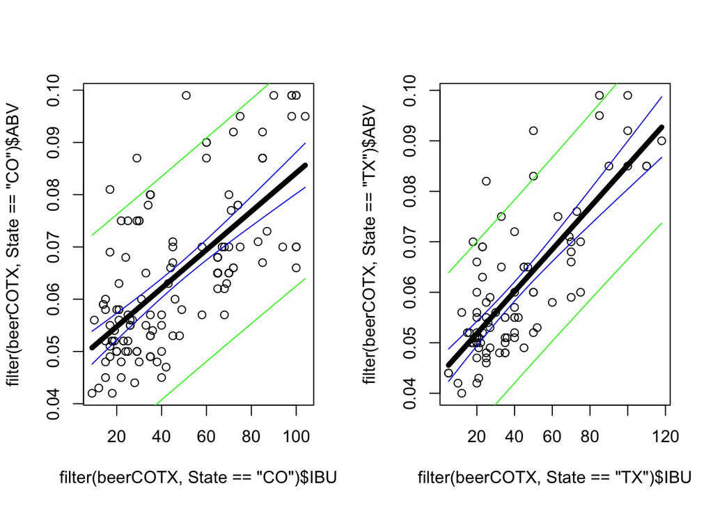

```r
#add the confidence intervals for the mean (blue) and predition intervals for the next observation the plots.
par(mfrow = c(1,2))
plot(filter(beerCOTX,State == "CO")$IBU,filter(beerCOTX,State == "CO")$ABV)
lines(filter(beerCOTX,State == "CO")$IBU,predsCO_CI[,1], lwd = 5)
lines(filter(beerCOTX,State == "CO")$IBU,predsCO_CI[,2], col = "blue")
lines(filter(beerCOTX,State == "CO")$IBU,predsCO_CI[,3], col = "blue")
lines(filter(beerCOTX,State == "CO")$IBU,predsCO_PI[,2], col = "green")
lines(filter(beerCOTX,State == "CO")$IBU,predsCO_PI[,3], col = "green")

plot(filter(beerCOTX,State == "TX")$IBU,filter(beerCOTX,State == "TX")$ABV)
lines(filter(beerCOTX,State == "TX")$IBU,predsTX_CI[,1], lwd = 5)
lines(filter(beerCOTX,State == "TX")$IBU,predsTX_CI[,2], col = "blue")
lines(filter(beerCOTX,State == "TX")$IBU,predsTX_CI[,3], col = "blue")
lines(filter(beerCOTX,State == "TX")$IBU,predsTX_PI[,2], col = "green")
lines(filter(beerCOTX,State == "TX")$IBU,predsTX_PI[,3], col = "green")
```

```r
#calcluate the prediction interval for the IBU = 64
newIBU = data.frame(IBU = 64)
predict(fitCO,interval = "prediction", newdata = newIBU)
```

```
##          fit        lwr        upr
## 1 0.07092568 0.04953248 0.09231889
```

```r
predict(fitTX,interval = "prediction", newdata = newIBU)
```

```
##          fit        lwr        upr
## 1 0.07017464 0.05194855 0.08840074
```

# Unit 10 & 11 HW

11. Now use the ASE loss function and external cross validation to provide evidence as to which model (the linear regression model from last week or the “best” KNN regression model from this week (from question 10)) is more appropriate.
12. Use your “best” KNN regression model to predict the ABV for an IBU of 150, 170 and 190. What issue do you see with using KNN to extrapolate?

BONUS (5 pts total): We did not have a lot data to build and test this classifier. Check out the class package’s knn.cv function that will perform leave-one-out cross validation.

What is leave-one-out CV (2pts)?

Get the accuracy metric for from this function for both the k = 3 and k = 5 KNN classifiers (2pts).

Which model is suggested by the leave-one-out CV method (1pt)?

```r
attach(beerTX)
library(mlr)
summarizeColumns(beerTX)
```

```
##            name    type na         mean         disp       median
## 1    Brewery_ID integer  0 1.596742e+02 8.461622e+01  129.0000000
## 2     Beer_Name  factor  0           NA 9.775281e-01           NA
## 3       Beer_ID integer  0 1.733551e+03 6.799897e+02 2041.0000000
## 4           ABV numeric  0 6.032584e-02 1.420049e-02    0.0550000
## 5           IBU integer  0 4.039326e+01 2.627720e+01   33.0000000
## 6         Style  factor  0           NA 8.988764e-01           NA
## 7        Ounces numeric  0 1.280899e+01 1.615805e+00   12.0000000
## 8       Brew_ID integer  0 1.596742e+02 8.461622e+01  129.0000000
## 9  Brewery_Name  factor  0           NA 8.651685e-01           NA
## 10         City  factor  0           NA 8.539326e-01           NA
## 11        State  factor  0           NA 0.000000e+00           NA
## 12         IBU2 numeric  0 2.314348e+03 3.051963e+03 1089.0000000
## 13  rand_number numeric  0 4.860026e-01 3.053966e-01    0.4553193
##             mad          min          max nlevs
## 1    83.0256000 30.000000000 4.270000e+02     0
## 2            NA  0.000000000 2.000000e+00    87
## 3   483.3276000 44.000000000 2.600000e+03     0
## 4     0.0088956  0.040000000 9.900000e-02     0
## 5    19.2738000  5.000000000 1.180000e+02     0
## 6            NA  0.000000000 9.000000e+00    40
## 7     0.0000000 12.000000000 1.600000e+01     0
## 8    83.0256000 30.000000000 4.270000e+02     0
## 9            NA  0.000000000 1.200000e+01    23
## 10           NA  0.000000000 1.300000e+01    15
## 11           NA  0.000000000 8.900000e+01     1
## 12 1021.5114000 25.000000000 1.392400e+04     0
## 13    0.4062301  0.002640132 9.644855e-01     0
```

```r
library(caret)
#B. Compare two competing models: External Cross Validation
##8. For this assignment we will concentrate only on the Texas data!  Create a training and test set from the data (60%/40% split respectively).  Print a summary of each new data frame… there should be two: TrainingTX, TestTX.

set.seed(7) # Set Seed so that same sample can be reproduced in future also
# considering response variable as strata
#random training set and test set for CO Data

#random training set and test set for TX Data
beerTX = filter(beerCOTX,State == "TX")
data_part <- createDataPartition(y = beerTX$ABV,  p = 0.60, list = F)
dim(beerTX) # 89
```

```
## [1] 89 12
```

```r
trainTX = beerTX[data_part,]
testTX = beerTX[-data_part,]
size_testTX = dim(testTX)[1]

fitTX = lm(ABV~IBU,data = filter(beerCOTX,State == "TX"))

ltrainTX = length(trainTX$ABV)
ltestTX = length(testTX$ABV)

perc_test = ltestTX / (ltestTX + ltrainTX)
perc_train = ltrainTX / (ltestTX + ltrainTX)
perc_test
```

```
## [1] 0.3820225
```

```r
perc_train
```

```
## [1] 0.6179775
```

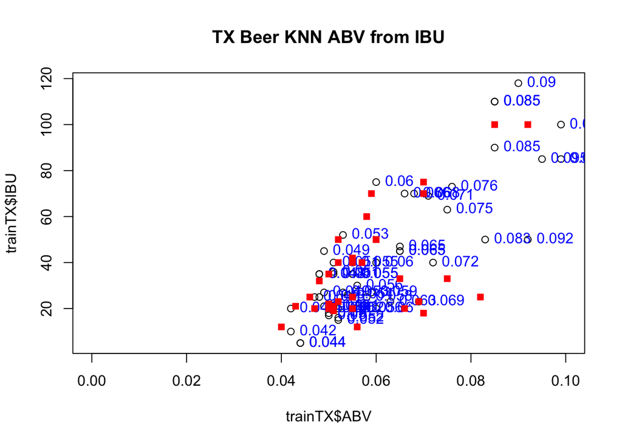

```r
##9.Using the training dat, fit a KNN regression model to predict ABV from IBU.  You should use the knnreg function in the caret package.  Fit two separate models: one with k = 3 and one with k = 5.  (This is 2 models total.)

plot(trainTX$ABV, trainTX$IBU, main = "TX Beer KNN ABV from IBU", xlim = c(0,.1))
text(trainTX$ABV, trainTX$IBU, labels = trainTX$ABV, pos = 4, col = "blue")
points(testTX$ABV, testTX$IBU,col = "red", pch = 15)
```

```r
fit =  knnreg(x = trainTX[,c(1,1)], y = trainTX$IBU, k = 3)
predict(fitTX,testTX[,c(1,1)])
```

```
##          1          2          3          4          5          6
## 0.04555967 0.04555967 0.04764569 0.04848009 0.04848009 0.04973170
##          7          8          9         10         11         12
## 0.05014891 0.05056611 0.05098331 0.05098331 0.05140051 0.05181772
##         13         14         15         16         17         18
## 0.05181772 0.05181772 0.05181772 0.05181772 0.05181772 0.05181772
##         19         20         21         22         23         24
## 0.05181772 0.05181772 0.05181772 0.05181772 0.05223492 0.05223492
##         25         26         27         28         29         30
## 0.05223492 0.05223492 0.05265212 0.05306933 0.05306933 0.05306933
##         31         32         33         34         35         36
## 0.05306933 0.05390373 0.05390373 0.05390373 0.05390373 0.05390373
##         37         38         39         40         41         42
## 0.05390373 0.05432093 0.05473814 0.05473814 0.05473814 0.05598975
##         43         44         45         46         47         48
## 0.05682415 0.05724135 0.05724135 0.05807576 0.05807576 0.05807576
##         49         50         51         52         53         54
## 0.05807576 0.05807576 0.05807576 0.05849296 0.06016177 0.06016177
##         55         56         57         58         59         60
## 0.06016177 0.06016177 0.06016177 0.06016177 0.06016177 0.06099618
##         61         62         63         64         65         66
## 0.06224779 0.06224779 0.06224779 0.06308219 0.06433380 0.06433380
##         67         68         69         70         71         72
## 0.06433380 0.06433380 0.06433380 0.06516821 0.06850583 0.06975744
##         73         74         75         76         77         78
## 0.07226066 0.07267786 0.07267786 0.07267786 0.07267786 0.07392947
##         79         80         81         82         83         84
## 0.07476387 0.07476387 0.07893590 0.07893590 0.08102192 0.08519395
##         85         86         87         88         89
## 0.08519395 0.08519395 0.08936597 0.08936597 0.09270360
```

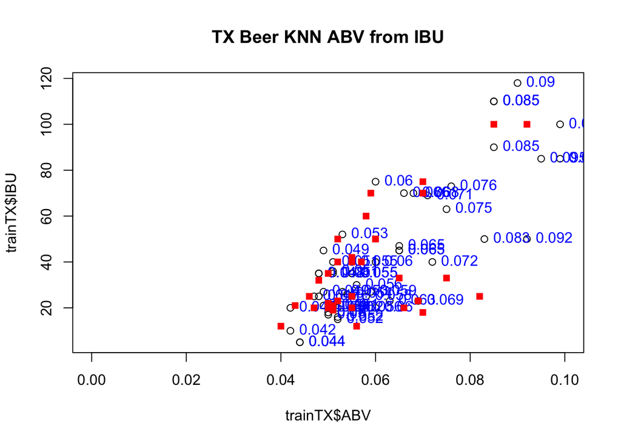

```r
plot(trainTX$ABV, trainTX$IBU, main = "TX Beer KNN ABV from IBU", xlim = c(0,.1))
text(trainTX$ABV, trainTX$IBU, labels = trainTX$ABV, pos = 4, col = "blue")
points(testTX$ABV, testTX$IBU,col = "red", pch = 15)
```

```r
fit =  knnreg(x = trainTX[,c(1,1)], y = trainTX$IBU, k = 5)
predict(fitTX,testTX[,c(1,1)])
```

```
##          1          2          3          4          5          6
## 0.04555967 0.04555967 0.04764569 0.04848009 0.04848009 0.04973170
##          7          8          9         10         11         12
## 0.05014891 0.05056611 0.05098331 0.05098331 0.05140051 0.05181772
##         13         14         15         16         17         18
## 0.05181772 0.05181772 0.05181772 0.05181772 0.05181772 0.05181772
##         19         20         21         22         23         24
## 0.05181772 0.05181772 0.05181772 0.05181772 0.05223492 0.05223492
##         25         26         27         28         29         30
## 0.05223492 0.05223492 0.05265212 0.05306933 0.05306933 0.05306933
##         31         32         33         34         35         36
## 0.05306933 0.05390373 0.05390373 0.05390373 0.05390373 0.05390373
##         37         38         39         40         41         42
## 0.05390373 0.05432093 0.05473814 0.05473814 0.05473814 0.05598975
##         43         44         45         46         47         48
## 0.05682415 0.05724135 0.05724135 0.05807576 0.05807576 0.05807576
##         49         50         51         52         53         54
## 0.05807576 0.05807576 0.05807576 0.05849296 0.06016177 0.06016177
##         55         56         57         58         59         60
## 0.06016177 0.06016177 0.06016177 0.06016177 0.06016177 0.06099618
##         61         62         63         64         65         66
## 0.06224779 0.06224779 0.06224779 0.06308219 0.06433380 0.06433380
##         67         68         69         70         71         72
## 0.06433380 0.06433380 0.06433380 0.06516821 0.06850583 0.06975744
##         73         74         75         76         77         78
## 0.07226066 0.07267786 0.07267786 0.07267786 0.07267786 0.07392947
##         79         80         81         82         83         84
## 0.07476387 0.07476387 0.07893590 0.07893590 0.08102192 0.08519395
##         85         86         87         88         89
## 0.08519395 0.08519395 0.08936597 0.08936597 0.09270360
```

```r
#summarize train and test dataset by columns
head(trainTX)
```

```
##   Brewery_ID                   Beer_Name Beer_ID   ABV IBU
## 1         67          Yo Soy Un Berliner    2520 0.044   5
## 2        129       18th Anniversary Gose    2370 0.044   5
## 3         67                     Rye Wit    2522 0.042  10
## 6        126                Weisse Versa     464 0.052  15
## 7        126         Weisse Versa (2012)    2374 0.052  16
## 8        188 Robert Earl Keen Honey Pils    2144 0.050  17
##                Style Ounces Brew_ID               Brewery_Name
## 1 Berliner Weissbier     12      67   Freetail Brewing Company
## 2               Gose     12     129   Real Ale Brewing Company
## 3            Witbier     12      67   Freetail Brewing Company
## 6         Hefeweizen     12     126    Karbach Brewing Company
## 7         Hefeweizen     12     126    Karbach Brewing Company
## 8   American Pilsner     12     188 Pedernales Brewing Company
##             City State IBU2
## 1    San Antonio    TX   25
## 2         Blanco    TX   25
## 3    San Antonio    TX  100
## 6        Houston    TX  225
## 7        Houston    TX  256
## 8 Fredericksburg    TX  289
```

```r
head(testTX)
```

```
##    Brewery_ID                          Beer_Name Beer_ID   ABV IBU
## 4         188                          Lobo Lito    2238 0.040  12
## 5         216                      Broken Bridge    2117 0.056  12
## 10        258                         LuckenBock    1972 0.070  18
## 11         39                          Twisted X    2212 0.051  19
## 13        119                   Bombshell Blonde     856 0.050  20
## 15        126 Love Street Summer Seasonal (2014)    1235 0.047  20
##                     Style Ounces Brew_ID                  Brewery_Name
## 4             Light Lager     12     188    Pedernales Brewing Company
## 5            Dunkelweizen     12     216            Texian Brewing Co.
## 10                   Bock     16     258          South Austin Brewery
## 11 American Adjunct Lager     12      39     Twisted X Brewing Company
## 13    American Blonde Ale     16     119 Southern Star Brewing Company
## 15                 Kölsch     12     126       Karbach Brewing Company
##                City State IBU2
## 4    Fredericksburg    TX  144
## 5          Richmond    TX  144
## 10     South Austin    TX  324
## 11 Dripping Springs    TX  361
## 13           Conroe    TX  400
## 15          Houston    TX  400
```

```r
summarizeColumns(trainTX)
```

```
##            name    type na         mean         disp   median          mad
## 1    Brewery_ID integer  0 1.555636e+02 9.207882e+01  127.000   88.9560000
## 2     Beer_Name  factor  0           NA 9.636364e-01       NA           NA
## 3       Beer_ID integer  0 1.707582e+03 7.284838e+02 2042.000  492.2232000
## 4           ABV numeric  0 6.132727e-02 1.538163e-02    0.055    0.0103782
## 5           IBU integer  0 4.234545e+01 2.807610e+01   35.000   22.2390000
## 6         Style  factor  0           NA 8.909091e-01       NA           NA
## 7        Ounces numeric  0 1.287273e+01 1.667273e+00   12.000    0.0000000
## 8       Brew_ID integer  0 1.555636e+02 9.207882e+01  127.000   88.9560000
## 9  Brewery_Name  factor  0           NA 8.363636e-01       NA           NA
## 10         City  factor  0           NA 8.363636e-01       NA           NA
## 11        State  factor  0           NA 0.000000e+00       NA           NA
## 12         IBU2 numeric  0 2.567073e+03 3.342818e+03 1225.000 1223.1450000
##       min       max nlevs
## 1  30.000   427.000     0
## 2   0.000     2.000    54
## 3  44.000  2600.000     0
## 4   0.042     0.099     0
## 5   5.000   118.000     0
## 6   0.000     6.000    31
## 7  12.000    16.000     0
## 8  30.000   427.000     0
## 9   0.000     9.000    20
## 10  0.000     9.000    15
## 11  0.000    55.000     1
## 12 25.000 13924.000     0
```

```r
summarizeColumns(testTX)
```

```
##            name    type na         mean         disp   median        mad
## 1    Brewery_ID integer  0 1.663235e+02 7.173171e+01  135.000  40.030200
## 2     Beer_Name  factor  0           NA 9.705882e-01       NA         NA
## 3       Beer_ID integer  0 1.775559e+03 6.014045e+02 2039.500 390.665100
## 4           ABV numeric  0 5.870588e-02 1.209189e-02    0.055   0.007413
## 5           IBU integer  0 3.723529e+01 2.312556e+01   28.500  13.343400
## 6         Style  factor  0           NA 8.823529e-01       NA         NA
## 7        Ounces numeric  0 1.270588e+01 1.547812e+00   12.000   0.000000
## 8       Brew_ID integer  0 1.663235e+02 7.173171e+01  135.000  40.030200
## 9  Brewery_Name  factor  0           NA 8.823529e-01       NA         NA
## 10         City  factor  0           NA 8.235294e-01       NA         NA
## 11        State  factor  0           NA 0.000000e+00       NA         NA
## 12         IBU2 numeric  0 1.905529e+03 2.504901e+03  824.500 658.274400
##       min       max nlevs
## 1   39.00   396.000     0
## 2    0.00     1.000    34
## 3  501.00  2526.000     0
## 4    0.04     0.092     0
## 5   12.00   100.000     0
## 6    0.00     4.000    19
## 7   12.00    16.000     0
## 8   39.00   396.000     0
## 9    0.00     4.000    19
## 10   0.00     6.000    13
## 11   0.00    34.000     1
## 12 144.00 10000.000     0
```

```r
#description of train and test data
trainTask <- makeClassifTask(data = trainTX, target = "Style")
testTask <- makeClassifTask(data = testTX, target = "Style")
trainTask
```

```
## Supervised task: trainTX
## Type: classif
## Target: Style
## Observations: 55
## Features:
##    numerics     factors     ordered functionals
##           7           4           0           0
## Missings: FALSE
## Has weights: FALSE
## Has blocking: FALSE
## Has coordinates: FALSE
## Classes: 31
##                                                           Altbier
##                                1                                1
##       American Amber / Red Lager               American Black Ale
##                                2                                1
##              American Blonde Ale               American Brown Ale
##                                5                                1
##   American Double / Imperial IPA American Double / Imperial Stout
##                                6                                1
##                     American IPA          American Pale Ale (APA)
##                                6                                5
##                 American Pilsner                   American Stout
##                                1                                1
##               Berliner Weissbier                   Bière de Garde
##                                1                                1
##                        Cream Ale                     Dunkelweizen
##                                1                                1
##                   English Bitter                English Brown Ale
##                                1                                1
##     English India Pale Ale (IPA)           Foreign / Export Stout
##                                1                                1
##                  German Pilsener                             Gose
##                                1                                1
##                       Hefeweizen       Keller Bier / Zwickel Bier
##                                2                                1
##            Maibock / Helles Bock              Munich Dunkel Lager
##                                1                                1
##              Munich Helles Lager                          Old Ale
##                                1                                1
##           Saison / Farmhouse Ale                      Smoked Beer
##                                3                                1
##                          Witbier
##                                3
## Positive class: NA
```

```r
str(getTaskData(trainTask))
```

```
## 'data.frame':    55 obs. of  12 variables:
##  $ Brewery_ID  : int  67 129 67 126 126 188 30 67 119 215 ...
##  $ Beer_Name   : Factor w/ 54 levels "1836","18th Anniversary Gose",..: 54 2 41 51 52 39 50 4 7 46 ...
##  $ Beer_ID     : int  2520 2370 2522 464 2374 2144 1050 2524 44 2124 ...
##  $ ABV         : num  0.044 0.044 0.042 0.052 0.052 0.05 0.05 0.042 0.05 0.06 ...
##  $ IBU         : int  5 5 10 15 16 17 18 20 20 20 ...
##  $ Style       : Factor w/ 31 levels "","Altbier","American Amber / Red Lager",..: 13 22 31 23 23 11 15 27 5 31 ...
##  $ Ounces      : num  12 12 12 12 12 12 16 12 12 12 ...
##  $ Brew_ID     : int  67 129 67 126 126 188 30 67 119 215 ...
##  $ Brewery_Name: Factor w/ 20 levels "Armadillo Ale Works",..: 6 15 6 10 10 14 3 6 17 2 ...
##  $ City        : Factor w/ 15 levels "Austin","Blanco",..: 13 2 13 11 11 10 14 13 4 11 ...
##  $ State       : Factor w/ 1 level "TX": 1 1 1 1 1 1 1 1 1 1 ...
##  $ IBU2        : num  25 25 100 225 256 289 324 400 400 400 ...
```

```r
##10.  Use the ASE loss function and external cross validation to provide evidence as to which model (k = 3 or k = 5) is more appropriate.  Remember your answer should be supported with why you feel a certain model is appropriate.  Your analysis should include the average squared error (ASE) for each model from the test set.  Your analysis should also include a clear discussion, using the ASEs, as to which model you feel is more appropriate.
###ASE=  (∑▒(y ̃_i-y_i )^2 )/n
###Here y ̃_i is the predicted ABV for the ith beer, y_iis the actual ABV of the ith beer and n is the sample size.
##11.  Now use the ASE loss function and external cross validation to provide evidence as to which model (the linear regression model from last week or the “best” KNN regression model from this week (from question 10)) is more appropriate.

##12.  Use your “best” KNN regression model to predict the ABV for an IBU of 150, 170 and 190.  What issue do you see with using KNN to extrapolate?
#TEXAS
#fit the first model to the training set
fit1TX = lm(ABV~IBU, data = trainTX)
#get predictions for the test data from the model fit on the training data
predsTX = predict(fit1TX,newdata = data.frame(IBU = testTX$IBU))
#Calculate the RMSE loss function
RMSE1TX = sqrt(sum((testTX$ABV - predsTX)^2)/size_testTX) # 34 is the size of the test set.
RMSE1TX
```

```
## [1] 0.009863284
```

```r
#fit the second (deg 2) model to the training set
fit2TX = lm(ABV~IBU + IBU2, data = trainTX)
#get predictions for the test data from the model fit on the training data
predsTX = predict(fit2TX,newdata = data.frame(IBU = testTX$IBU, IBU2 = testTX$IBU2))
#Calculate the RMSE loss function
RMSE2TX = sqrt(sum((testTX$ABV - predsTX)^2)/size_testTX) # 34 is the size of the test set.
RMSE2TX
```

```
## [1] 0.00998691
```

BONUS (5 pts total): We did not have a lot data to build and test this classifier. Check out the class package’s knn.cv function that will perform leave-one-out cross validation.

Get the accuracy metric for from this function for both the k = 3 and k = 5 KNN classifiers (2pts).

Which model is suggested by the leave-one-out CV method (1pt)?